# Markov chain Monte Carlo sampling algorithms

Lecture 2

Dr Samuel Livingstone

# Last time

- Introduction to sampling & Monte Carlo
- Direct sampling via inverse CDF method
- Rejection sampling
- Importance sampling

# Today - towards more advanced sampling algorithms!

- Motivation for Markov chain Monte Carlo (Bayesian inference setting)
- Markov chains on general state spaces
- One slide on MCMC

# Part 1: Motivation

# The need for better sampling algorithms

- So far we have learned:
  - Direct sampling (e.g. inverse CDF method)
  - Rejection sampling
  - Importance sampling and SIR
- **Problem 1.** Direct sampling is usually not possible for complex models
- **Problem 2.** Rejection and importance sampling usually suffer from the curse of dimensionality

# Rejection sampling example (1)

- Recall that in rejection sampling
  $$\mathbb{P}(\text{Accept candidate sample}) = \frac{1}{M}$$
- Consider a sequence of target distributions $\pi^{(1)}, \pi^{(2)},...$ with densities
  $$\pi^{(d)}(x^{(d)}) = (2\pi)^{-d/2} \exp\left\{-\frac{1}{2}
  \|x^{(d)}\|_2^2 \right\}$$
- **Questions.** Which distribution is this? What does $d$ represent?
- Set the sequence of candidate distributions $q^{(1)}, q^{(2)},...$ to have densities
  $$q^{(d)}(x^{(d)}) = (2\pi\sigma^2)^{-d/2}
  \exp\left\{-\frac{1}{2\sigma^2}\|x^{(d)}\|_2^2\right\}$$

# Rejection sampling example (2)

- The resulting sequence of $M^{(d)}$’s is
  $$M^{(d)} = \sup_{x^{(d)}} \frac{\pi^{(d)}(x^{(d)})}{q^{(d)}(x^{(d)})}$$
- This can be simplified to
  $$M^{(d)} = \sigma^d \sup_{x^{(d)}} \exp\left\{
  \frac{1}{2}\left(\frac{1}{\sigma^2} - 1 \right)\|x^{(d)}\|_2^2\right\}$$
- If $\sigma^2 < 1$ then $M = \infty$
  - (rejection sampling not possible)
- If $\sigma^2 > 1$ then $M = \sigma^d$
  - So $\mathbb{P}(\text{Accept candidate sample}) = \sigma^{-d}$, which **decreases exponentially with dimension**
- (This is an example of the *concentration of measure* phenomenon)

# Some remarks

- Importance sampling suffers a similar problem
  - variance of weights typically grows exponentially with dimension
- To solve this issue we will devise a new sampling strategy based on Markov chains
- But first - motivation for sampling in Bayesian inference

# Bayesian inference refresh

- The process and goal are the same as in any other type of model-based inference
  - Begin with some data
  - Design a family of probabilistic models for the data generating process, indexed by parameter $\theta \in \Theta$
  - We believe there is a best choice of $\theta_0 \in \Theta$ (either the ‘true’ model or closest approximation within the family)
  - We try to make a best inference for what $\theta_{0}\in\Theta$ is given the data
- The *big idea* (build a model for the data to learn things) does not change whichever inference procedure you use, only the details

# Bayes in a nutshell

- Choose a distribution over $\Theta$ space, expressing your beliefs about what $\theta_0 \in \Theta$ might be
  - the **prior distribution** with density $\pi_0(\theta)$
- Update the **prior** into a **posterior distribution** using Bayes’ theorem, e.g.
  $$\pi(\theta|y) = \frac{\pi_0(\theta)f(y|\theta)}{\int
  \pi_0(\vartheta)f(y|\vartheta)d\vartheta}$$
- **Question.** What is $f(y|\theta)$?

# Bayes: an example (1)

- We asked $10$ students that took STAT0044 (my module at UCL) if they enjoyed it
  $$X_i =
  \begin{cases}
  1 ~~~ \text{ if student liked STAT0044} \\
  0 ~~~ \text{ otherwise.}
  \end{cases}$$
- The model for the data is
  $$\begin{aligned}
  X_i | p
  &\sim \text{Bernoulli}(p),
  \\
  p
  &\sim U[0,1]
  \end{aligned}$$
- Of course all the students liked the module…
  - **Question.** So what are the 10 data points?

# Bayes: an example (2)

- This means
  $$\begin{aligned}
  \pi(p|x)
  &= \frac{f(x|p)\pi_0(p)}{\int f(x|p)\pi_0(p)dp} \\
  &= \frac{(p^n \cdot 1) \mathbb{I}_{[0,1]}(p)}{\int_0^1 {p}^n \cdot 1
  dp} \\
  &= (n+1)p^n\mathbb{I}_{[0,1]}(p).
  \end{aligned}$$
- Recall that the Beta$(\alpha,\beta)$ distribution has pdf
  $$f(p) \propto p^{\alpha - 1}(1-p)^{\beta - 1}\mathbb{I}_{[0,1]}(p)$$
- **Question:** So what is the posterior distribution here?

# Bayes: an example

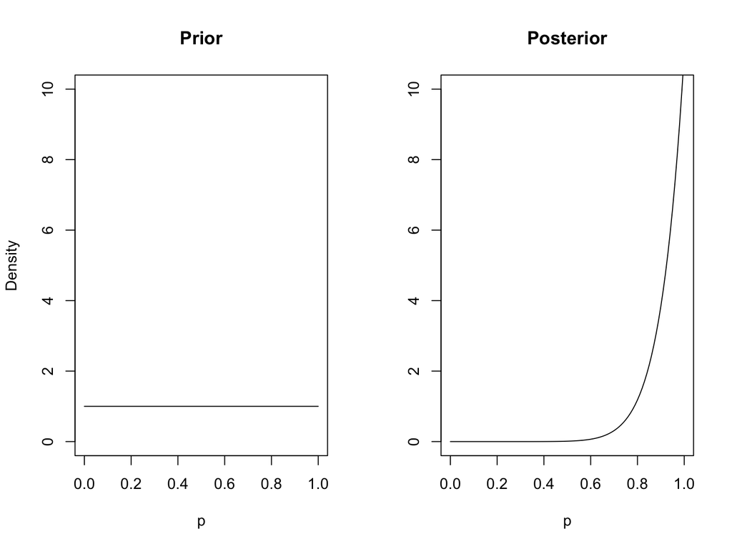

```r
par(mfrow = c(1,2))

n <- 10
f1 <- function(x) { dbeta(x, shape1 = 1, shape2 = 1) }
f2 <- function(x) { dbeta(x, shape1 = 1+n, shape2 = 1) }

curve(f1, from = 0, to = 1, main = "Prior", xlab = "p", ylab = "Density", ylim = c(0,10))
curve(f2, from = 0, to = 1, main = "Posterior", xlab = "p", ylab = "", ylim = c(0,10))
```

# Bayes: another example

- Consider the same model, but now we choose a different prior
  $$p \sim \pi_0$$
- Now the posterior is
  $$\pi(p|x)
  \propto f(x|p)\pi_0(p)$$
- This is as far as we can go. We only know $\pi(p|x)$ up to a constant, so we cannot normalise it
- So to compute expectations wrt $\pi(\cdot|x)$ we are in the realm of **the integration problem** from lecture 1!

# There are pros and cons to Bayes, just like any other approach!

- Some pros:
  - Easy to predict whilst incorporating parameter uncertainty.
    $$p(y'|y)=\int f(y'|\theta)\pi(\theta|y)d\theta$$
  - Marginal uncertainty is easy: compute the marginal posterior
    $$\pi(\theta_1|y) = \int \pi(\theta|y)d\theta_2...d\theta_d$$
  - Prior is often used as a *regulariser.* Most agree that regularisation is good!
- Some cons:
  - The prior can be hard to construct
  - **Expectations wrt the posterior requires integration! (often intractable)**

# How to integrate with respect to a high-dimensional unnormalised posterior?

- There is an entire field dedicated to this: **Bayesian computation**.
- Some of the approaches we have learned about can be used/modified when only $c\pi$ is known ($c \in [0,\infty)$)
  - But as we have seen, they often they succumb to the curse of dimensionality
- To beat this, we relax the problem setting
  - Rather than drawing independent samples, let them be dependent
  - Rather than sampling from $\pi$, just try to get as close as we can
- This is the realm of Markov chain Monte Carlo!

# Part 2: General state space Markov chains

# Markov chain

**Definition** An $E$-valued discrete-time stochastic process $\{X_{t}\}_{t\geq0}$ is called a **Markov chain** if for any fixed $t$ and any $x_{t}\in E$ the random variable
$$X_{t+1}|(X_{t}=x_{t})$$
is independent of $X_{t-k}$ for all $t \geq k \geq 1$.

- Symbolically this can be written
  $$\left(X_{t+1}\perp\!\!\!\perp X_{t-k}\right)|X_{t}.$$
- In words **the future is independent of the past if we know the present.**
- The Markov property in terms of probabilities (ignoring measure theoretic subtleties)
  $$\mathbb{P}\left(X_{t+1}\in
  A|X_{t}=x_{t},...,X_{0}=x_{0}\right)=\mathbb{P}\left(X_{t+1}\in
  A|X_{t}=x_{t}\right)$$

# To simulate a Markov chain, we need only two things

- An *initial distribution* $\mu_{0}$, such that $\mathbb{P}(X_{0}\in A):=\mu_0(A)$ for all $A\in\mathcal{E}$
- A *transition kernel*
  $$P(x,A) := \mathbb{P}(X_{i} \in A|X_{i-1}=x)$$
  for all $A\in\mathcal{E}$ and all $x\in E$
- Then set $i=1$, draw $X_0 \sim \mu_0$ and repeat:
  1. Sample $X_{i}|X_{i-1}\sim P(X_{i-1},\cdot)$
  2. If $i<n$, set $i\to i+1$ and return to 1.
- We will focus on *time-homogeneous* chains, meaning $P$ does not depend on $t$.

# Example (finite state space)

Let $X_0 = 1$ or $2$ w.p. $1/2$, and introduce the matrix

$$\bar{P} = \left( \begin{array}{cc}
1/3 & 2/3 \\
2/3 & 1/3
\end{array}\right).$$

- Let $\mathbb{P}(X_{i}=y|X_{i-1}=x)=\bar{P}(x,y)$.
- $\bar{P}$ is called the transition matrix
- The transition *kernel* is
  $$P(x,A):=\sum_{y\in A}\bar{P}(x,y).$$
- Normally in finite state spaces we just work with the matrix
  - **Question.** Why can’t we do the same in continuous state spaces?

# Example (finite state space)

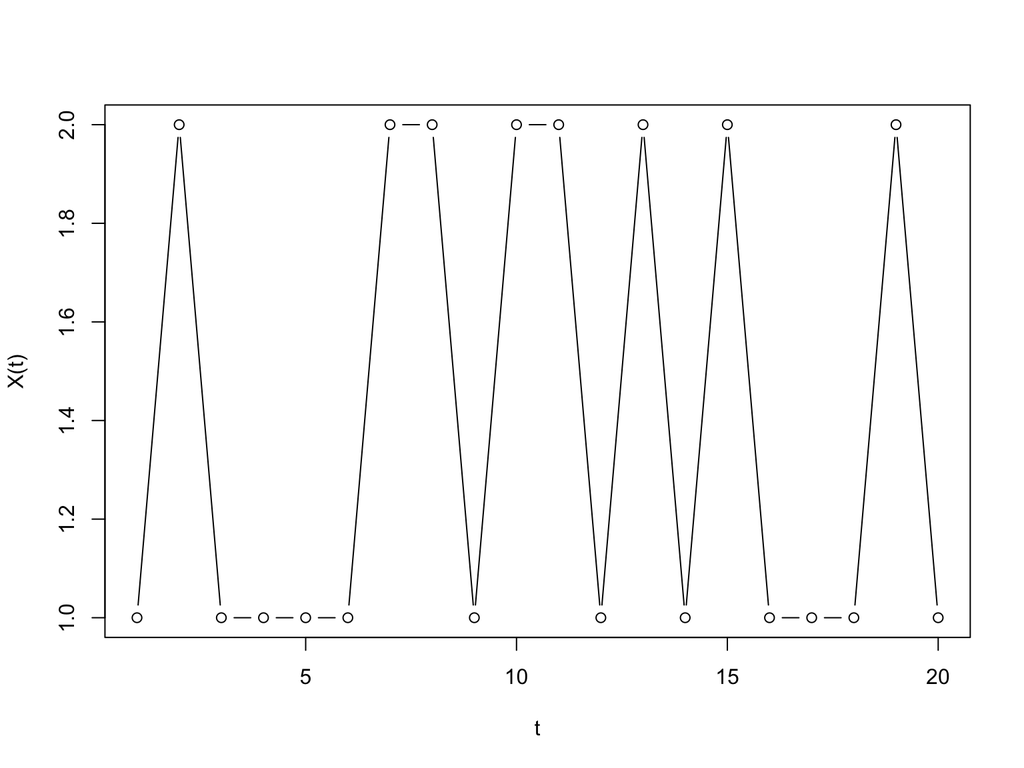

# Example (continuous state space)

- Let $X_0 \sim N(0,1)$ and introduce the recursion
  $$X_{i}=\gamma X_{i-1}+\sqrt{(1-\gamma^{2})}Z_{i},$$
  where each $Z_{i}\stackrel{iid}{\sim} N(0,1)$ and $\gamma\in\mathbb{R}$ with $|\gamma|<1$.
- Here the kernel is
  $$P(x,A)=\frac{1}{\sqrt{2\pi(1-\gamma^{2})}}\int_{y\in
  A}\exp\left(-\frac{1}{2(1-\gamma^{2})}(y-\gamma x)^{2}\right)dy.$$
- We can write $P(x,A) = \int_A p(x,y)dy$ and call $p(x,y)$ the **transition density**.
- More generally we can write $P(x,A) = \int_A P(x,dy)$

# Example (continuous state space, $X_0 = 20$, $\gamma = 0.8$)

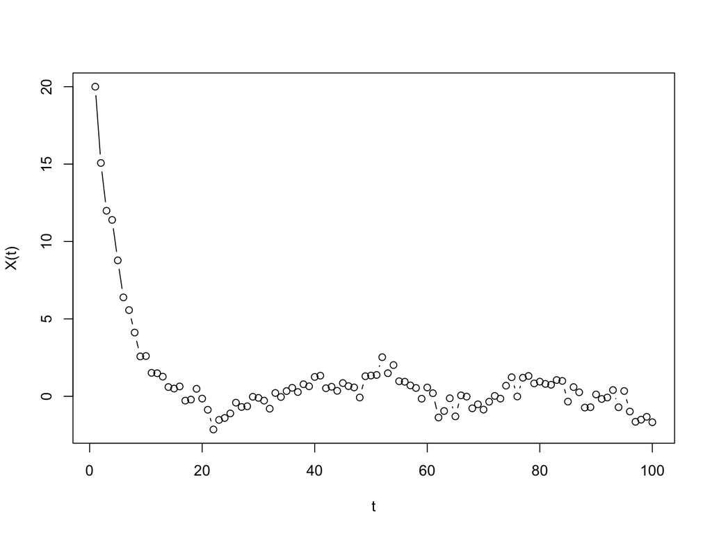

# Remark

- Often we will see that it’s convenient to describe the chain through the recursion
  $$X_{i+1} = f(X_i, \xi_{i+1}),$$
  where $X_i$ is the current state and $\xi_{i+1}$ is independent of $X_i$
- Sometimes called the *nonlinear state space model* (Meyn & Tweedie) or *iterated random function* (Diaconis & Freedman)
- The Markov property is clear if the process can be described in this way

# Marginal distributions

- If $X_0 \sim \mu$ and $X_{t+1}|(X_t = x) \sim P(x,\cdot)$, then the marginally
  $$\mathbb{P}(X_1 \in A) = \int P(x,A)\mu(dx).$$
- We sometimes define the probability measure $\mu P$ s.t. for any $A \in \mathcal{E}$
  $$\mu P(A) := \int \mu(dx)P(x,A)$$
  (and write $X_1 \sim \mu P$)
- Note that in the finite setting this integral can be re-written
  $$\begin{aligned}
  \mathbb{P}(X_1 \in A)
  &=
  \sum_{x \in E} \mu(\{x\})P(x,A)
  \\
  &=
  \sum_{x \in E} \mathbb{P}(X_0 =x) \mathbb{P}(X_1 \in A |X_0 = x)
  \end{aligned}$$
  (i.e. just the law of total probability)

# Calculating marginal distributions: Example 1

- Let $E =\{1,2\}$, $\mu = \delta_1$, $\bar{P} = \begin{pmatrix} 1/3 & 2/3 \\ 2/3 & 1/3 \\ \end{pmatrix}$
- Then for any $A \in \mathcal{E}$
  $$\mu P (A) = \int \delta_1(dx)P(x,A) = P(1,A).$$
- In more classical vector notation we could write
  $$\mu = (1,0), ~~~~ \mu P = (1/3, 2/3)$$
- **Question.** What would $\mu P$ be if instead $\mu = (0, 1)$?

# Calculating marginal distributions: Example 2

- Let $E = \mathbb{R}$, $\mu = \frac{1}{2}\delta_{-1} + \frac{1}{2}\delta_1$ and
  $$P(x,A) = \int_A \phi(y-x)dy$$
  where $\phi(z) = e^{-z^2/2}/\sqrt{2\pi}$ is a standard Normal density.
- **Question.** What is the (famous) name of this type of Markov chain?
- Then for any $A \in\mathcal{E}$
  $$\begin{aligned}
  \mu P (A)
  &=
  \int \mu(dx)P(x, A)
  \\
  &=
  \int \left( \frac{1}{2}\delta_{-1}(dx) + \frac{1}{2}
  \delta_1(dx)\right)P(x,A)
  \\
  &=
  \frac{1}{2}P(-1,A) + \frac{1}{2}P(1,A)
  \\
  &=
  \frac{1}{2}\int_A \phi(y+1)dy + \frac{1}{2}\int_A \phi(y-1)dy
  \end{aligned}$$
- **Question.** So if $X_0 \sim \mu$, what is the distribution of $X_1$ under this Markov chain?

# Finite state space example re-visited

- With $\bar{P}$ as above, recall the Chapman–Kolmogorov equations
  $$\mathbb{P}(X_{t+n} = y|X_t = x) = \bar{P}^n(x,y)$$
- Examining this matrix for different values of $n$ gives
  $$\begin{aligned}
  \bar{P} & =\left(\begin{array}{cc}
  1/3 & 2/3\\
  2/3 & 1/3
  \end{array}\right)\\
  \bar{P}^{2} & =\left(\begin{array}{cc}
  0.55 & 0.44\\
  0.44 & 0.55
  \end{array}\right)\\
  \bar{P}^{5} & =\left(\begin{array}{cc}
  0.498 & 0.502\\
  0.502 & 0.498
  \end{array}\right)
  \end{aligned}$$
- **Question.** What is happening to each row of $\bar{P}^{n}$ as $n\to\infty$?

# Forgetting the initial state

- Many Markov chains have the property that when $n$ is large the distribution of $X_{n}$ begins to stabilise
- The phenomenon is called **convergence to equilibrium** or **mixing**
- To define it mathematically we will need a precise notion of **distance** between distributions

# Measuring the distance between distributions

- For now we will work with the **total variation distance** (TV). For distributions $\mu$ and $\nu$ on $(E,\mathcal{E})$
  $$\|\mu - \nu\|_{TV} := \sup_{A \in \mathcal{E}}|\mu(A) - \nu(A)|$$
- TV is within the family of **integral probability metrics**, so can also be written
  $$\|\mu - \nu\|_{TV} = \sup_{f :E \to [0,1]}|\mathbb{E}_\mu[f] -
  \mathbb{E}_\nu[f]|$$
- If $\mu$ and $\nu$ have densities then it can also be written (see exercises)
  $$\|\mu - \nu\|_{TV} = \frac{1}{2} \int |\mu(x) - \nu(x)|dx$$

# Convergence to equilibrium

- **Definition.** The *$n$-step transition kernel* is
  $$P^{n}(x,A):= \mathbb{P}(X_n \in A | X_0 = x)$$
- **Definition.** A Markov chain with transition kernel $P$ has a unique **limiting distribution** $\pi$ if for ($\pi-$almost) all starting points $x\in E$
  $$\lim_{n\to\infty}\| P^{n}(x,\cdot) - \pi \|_{TV}=0.$$
- In this instance we say the chain *converges to equilibrium* (or *mixes*)
- (For the general case $X_0 \sim \mu$ we can write $\lim_{n\to\infty}\|\mu P^n - \pi\|_{TV} = 0$)
  - **Question.** What choice of $\mu$ would bring us back to the case $\mu P^n = P^n(x,\cdot)$?
- To understand when convergence to equilibrium happens, we need some more properties of Markov chains.

# More properties of Markov chains

- A Markov chain with transition kernel $P$ is called:
  - *$\pi$-irreducible* if for every $A\in\mathcal{E}$ and every $x\in E$ there is an $n<\infty$ s.t.
    $$\pi(A)>0\implies P^{n}(x,A)>0.$$
  - *Aperiodic* if there is no collection of disjoint events $A_{0},...,A_{k-1}\in\mathcal{E}$ s.t.
    $$x\in A_{i}\implies P(x,A_{(i+1)\mod k})=1.$$
  - *$\pi$-invariant* if for all $n\geq0$
    $$X_{t}\sim\pi \implies X_{t+n} \sim \pi$$
- For most of the chains we will study $\pi$-irreducibility and aperiodicity are obvious, so we won’t dwell on them

# Example of $\pi$-invariance

- Take the continuous example
  $$X_{i+1} = \gamma X_i + \sqrt{1-\gamma^2}Z_{i+1},$$
  for $|\gamma|<1$ and $Z_{i+1} \sim N(0,1)$.
- Imagine that $X_i \sim N(0,1)$
- Then $X_{i+1}$ is a linear combination of independent Gaussians
  - **Question.** What does this imply about the distribution for $X_{i+1}$?
- $\mathbb{E}[X_{i+1}] = 0$ (Check!)
- For the variance we have
  $$\begin{aligned}
  \text{Var}[X_{i+1}] &= \gamma^2 \text{Var}[X_i] +
  (1-\gamma^2)\text{Var}[Z_i] \\
  &= \gamma^2 + (1 - \gamma^2) \\
  &= 1
  \end{aligned}$$
- So $N(0,1)$ is an invariant distribution

# Theorem: convergence to equilibrium

If a Markov chain with transition kernel $P$ is $\pi$-invariant, $\pi$-irreducible and aperiodic, then $\pi$ is the **unique limiting distribution** for the chain.

# Checking the conditions

- $\pi$-irreducibility and aperiodicity are often obvious (but not always!)
- $\pi$-invariance is not hard to check provided some more structure is imposed
- In most cases the structure is **reversibility**/**detailed balance**

# $\pi$-reversibility

- **Definition.** A finite state space chain with transition matrix $\bar{P}$ is *$\pi$-reversible* if
  $$\pi(x)\bar{P}(x,y) = \pi(y)\bar{P}(y,x)$$
  for all $x,y \in E$.
- For a general state space chain with a transition kernel $P$ the condition can be written
  $$\pi(dx)P(x,dy) = \pi(dy)P(y,dx)$$
- If $P(x,\cdot)$ has a *transition density* $p(x,y)$ for all $x \in E$ then $\pi$ has a density and we can write
  $$\pi(x)p(x,y) = \pi(y)p(y,x)$$
- (‘$P$ has a transition density $p$’ just means $P(x,A) = \int_A p(x,y)dy$)

# Example (re-visited again)

- Take the discrete two state example from earlier
  $$\bar{P} = \left( \begin{array}{cc}
  1/3 & 2/3 \\
  2/3 & 1/3
  \end{array}\right).$$
- Here
  $$\bar{P}(1,2) = \bar{P}(2,1),$$
- **Question.** So which distribution is this chain reversible with respect to?

# Theorem (reversibility $\implies$ invariance)

- If a Markov chain is $\pi$-reversible, then it is $\pi$-invariant.
- *Proof.* In the general case, we need to show for any $A \in \mathcal{E}$ that $X_n \sim \pi \implies X_{n+1} \sim \pi$
- Recall that if $X_n \sim \pi$ then
  $$\mathbb{P}(X_{n+1} \in A)
  =
  \int_{x_n \in E}\pi(dx_n)P(x_n, A)
  =
  \int_{x_{n+1} \in A} \int_{x_n \in E} \pi(dx_n)P(x_n, dx_{n+1})$$
- Now by $\pi$-reversibility $\pi(dx_n) P(x_n,dx_{n+1}) = \pi(dx_{n+1}) P(x_{n+1},dx_n)$, meaning we can instead write
  $$\mathbb{P}(X_{n+1} \in A) = \int_{x_n \in E} \int_{x_{n+1} \in A}
  \pi(dx_{n+1}) P(x_{n+1},dx_n)$$
- Using Fubini–Tonelli theorem the integrals can be switched around, meaning
  $$\mathbb{P}(X_{n+1} \in A) = \int_{x_{n+1} \in A} \left[ \int_{x_n \in E}
  P(x_{n+1},dx_n) \right] \pi(dx_{n+1})$$
- But since $P(x_{n+1}, \cdot)$ is a probability measure then $P(x_{n+1},E) = 1$, meaning
  $$\mathbb{P}(X_{n+1} \in A) = \int_{x_{n+1} \in A} \pi(dx_{n+1}) = \pi(A).$$

# The Markov chain ergodic theorem

If a Markov chain $\{X_{t}\}_{t\geq0}$ is $\pi$-irreducible and $\pi$-invariant, and $f: E \to\mathbb{R}$ satisfies $\mathbb{E}_{\pi}[f(X)]<\infty$, then the **ergodic average**
$$\hat{f}_{n}:= \frac{1}{n}\sum_{i=0}^{n-1}f(X_{i})$$
satisfies
$$\mathbb{P}\left(\lim_{n\to\infty}\hat{f}_{n}=\mathbb{E}_{\pi}[f(X)]\right)=1.$$

- **Question.** Which theorem about iid random variables is this similar to?

# Part 3: Markov chain Monte Carlo (1 slide)

# Markov chain Monte Carlo (basic idea)

- **Goal:** compute $\mathbb{E}_\pi[f]$, with only $c\pi$ known
- **Approach:**
  - Construct a Markov chain
    $$\{X_t\}_{t\geq 0}$$
    s.t. $\pi$ is the limiting distribution
  - Compute ergodic averages
    $$\frac{1}{n} \sum_{i=0}^{n-1} f(X_i) \approx \mathbb{E}_\pi[f].$$
- **But how can this be done??**

# End of lecture

We will find out next time!